# Семинар 6. Красотища

Июнь, 18, 2018

Шаманское заклинание для настройки глобальных опций отчёта:

Подключаем пакеты

```r
library(tidyverse) # обработка данных, графики...
library(skimr) # описательные статистики
library(rio) # импорт фантастического количества форматов данных
library(broom) # метла превращает результаты оценивания моделей в таблички
library(GGally) # больше готовых графиков
library(sjPlot) # ещё больше графиков
library(lmtest) # диагностика линейных моделей
library(sjstats) # удобные мелкие функции для работы с моделями
library(sandwich) # оценка Var для гетероскедастичности
library(AER) # работа с инструментальными переменными
library(Ecdat) # много-много разных наборов данных
library(huxtable) # красивые таблички в html, tex
library(stargazer) # красивые таблички в html, tex
library(texreg) # и снова красивые таблички в html, tex :)
library(estimatr) # модели с робастными ошибками
```

Заметим, что в данном случае, важно, какой пакет подключать раньше, `AER`, или `Ecdat`. Оба пакета содержат встроенный набор данных с названием `Mroz`, и эти наборы данных чуть-чуть отличаются. По умолчанию, активен набор данных `Mroz` из последнего подключённого пакета. Если нужен другой набор данных, то до него можно дотянуться, указав имя пакета в начале, `AER::Mroz`.

# Регрессия при гетероскедастичных ошибках

Если не предполагать, что дисперсии ошибок $Var(u_i)$ одинаковы для всех наблюдений, то построенные нами доверительные интервалы и выполненная проверка гипотез — полный отстой :)

Есть два подхода работать с робастными стандартными ошибками. Можно переоценить модель с помощью функций из пакета `estimatr`, а можно использовать ранее оцененные модели, указывая каждый раз нужную оценку ковариационной матрицы.

Загружаем данные и объявляем переменные факторными:

```r
pulse <- import('data/pulse.txt')
pulse_fct <- pulse %>%
  mutate_at(vars(-Weight, -Height, -Age, -Pulse1, -Pulse2), factor)
```

Оценим модели без учёта гетероскедастичности:

```r
model_r <- lm(data = pulse_fct, Pulse2 ~ Pulse1)
model_ur <- lm(data = pulse_fct, Pulse2 ~ Weight + Pulse1 + Ran + Smokes)
summary(model_ur)
```

```
##
## Call:
## lm(formula = Pulse2 ~ Weight + Pulse1 + Ran + Smokes, data = pulse_fct)
##
## Residuals:
##     Min      1Q  Median      3Q     Max
## -39.631  -3.717   0.170   4.360  42.354
##
## Coefficients:
##              Estimate Std. Error t value Pr(>|t|)
## (Intercept)  56.12572   12.14842   4.620 1.10e-05 ***
## Weight        0.02187    0.09113   0.240    0.811
## Pulse1        0.89417    0.10421   8.580 9.77e-14 ***
## Ran2        -52.20287    2.75215 -18.968  < 2e-16 ***
## Smokes2       1.90805    4.52173   0.422    0.674
## ---
## Signif. codes:  0 '***' 0.001 '**' 0.01 '*' 0.05 '.' 0.1 ' ' 1
##
## Residual standard error: 14.1 on 104 degrees of freedom
##   (1 observation deleted due to missingness)
## Multiple R-squared:  0.8078, Adjusted R-squared:  0.8004
## F-statistic: 109.3 on 4 and 104 DF,  p-value: < 2.2e-16
```

Способ с переоцениванием модели:

```r
model_r_rob <- lm_robust(data = pulse_fct, Pulse2 ~ Pulse1)
model_ur_rob <- lm_robust(data = pulse_fct, Pulse2 ~ Weight + Pulse1 + Ran + Smokes)
summary(model_ur_rob)
```

```
##
## Call:
## lm_robust(formula = Pulse2 ~ Weight + Pulse1 + Ran + Smokes,
##     data = pulse_fct)
##
## Standard error type:  HC2
##
## Coefficients:
##              Estimate Std. Error  Pr(>|t|) CI Lower CI Upper  DF
## (Intercept)  56.12572   18.32138 2.787e-03  19.7937  92.4577 104
## Weight        0.02187    0.08825 8.047e-01  -0.1531   0.1969 104
## Pulse1        0.89417    0.18665 5.541e-06   0.5240   1.2643 104
## Ran2        -52.20287    3.14263 5.027e-31 -58.4348 -45.9709 104
## Smokes2       1.90805    2.34735 4.182e-01  -2.7468   6.5629 104
##
## Multiple R-squared:  0.8078 ,    Adjusted R-squared:  0.8004
## F-statistic: 78.48 on 4 and 104 DF,  p-value: < 2.2e-16
```

Проверка гипотез и доверительные интервалы с робастно оценёнными моделями:

```r
coeftest(model_ur_rob)
```

```
##
## t test of coefficients:
##
##               Estimate Std. Error  t value  Pr(>|t|)
## (Intercept)  56.125722  18.321380   3.0634  0.002787 **
## Weight        0.021875   0.088252   0.2479  0.804727
## Pulse1        0.894167   0.186648   4.7907 5.541e-06 ***
## Ran2        -52.202870   3.142630 -16.6112 < 2.2e-16 ***
## Smokes2       1.908051   2.347350   0.8129  0.418159
## ---
## Signif. codes:  0 '***' 0.001 '**' 0.01 '*' 0.05 '.' 0.1 ' ' 1
```

```r
coefci(model_ur_rob)
```

```
##                   2.5 %      97.5 %
## (Intercept)  19.7937381  92.4577056
## Weight       -0.1531328   0.1968823
## Pulse1        0.5240371   1.2642973
## Ran2        -58.4348228 -45.9709175
## Smokes2      -2.7468326   6.5629340
```

```r
coefci(model_ur)
```

```
##                   2.5 %      97.5 %
## (Intercept)  32.0349494  80.2164943
## Weight       -0.1588415   0.2025909
## Pulse1        0.6875121   1.1008223
## Ran2        -57.6604911 -46.7452493
## Smokes2      -7.0587150  10.8748163
```

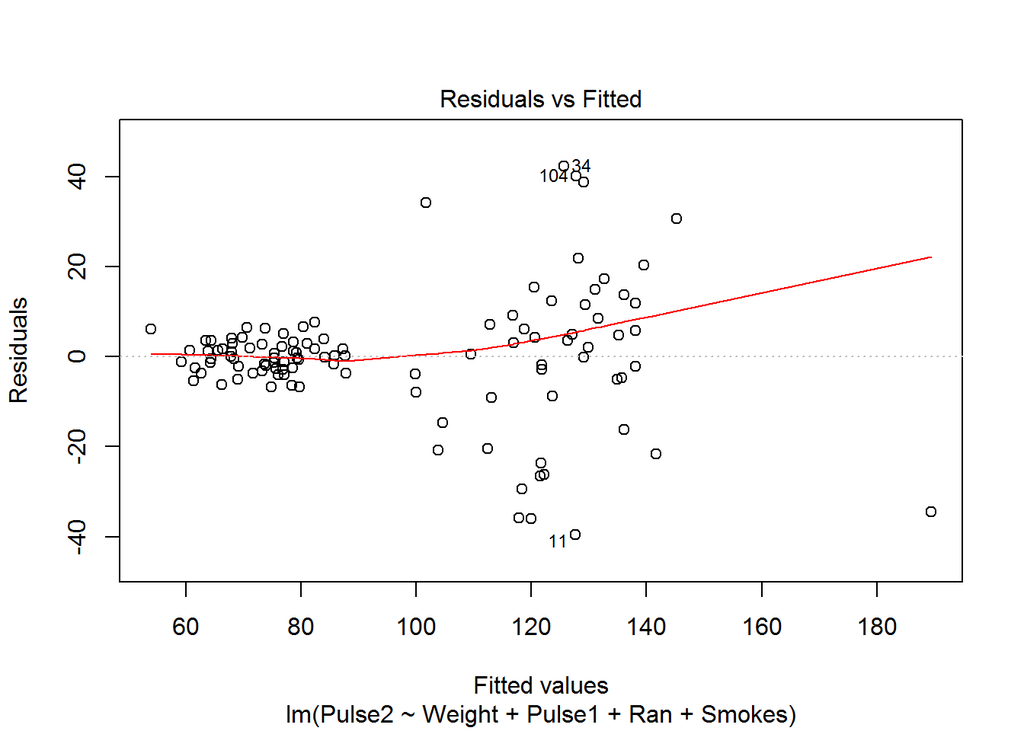

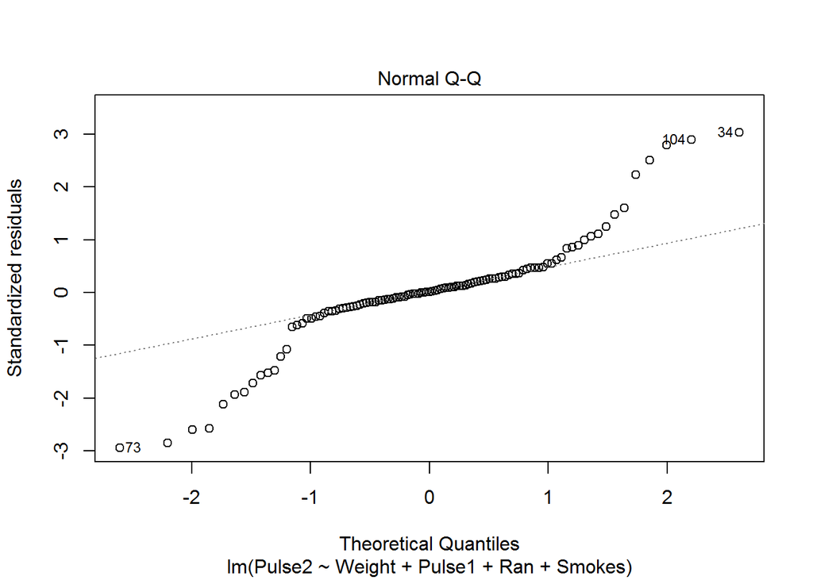

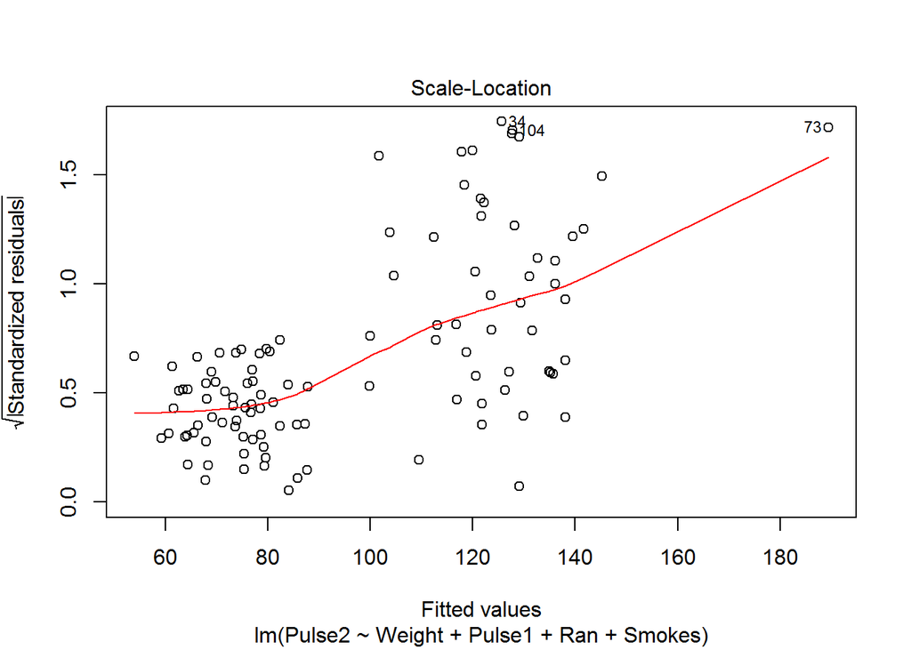

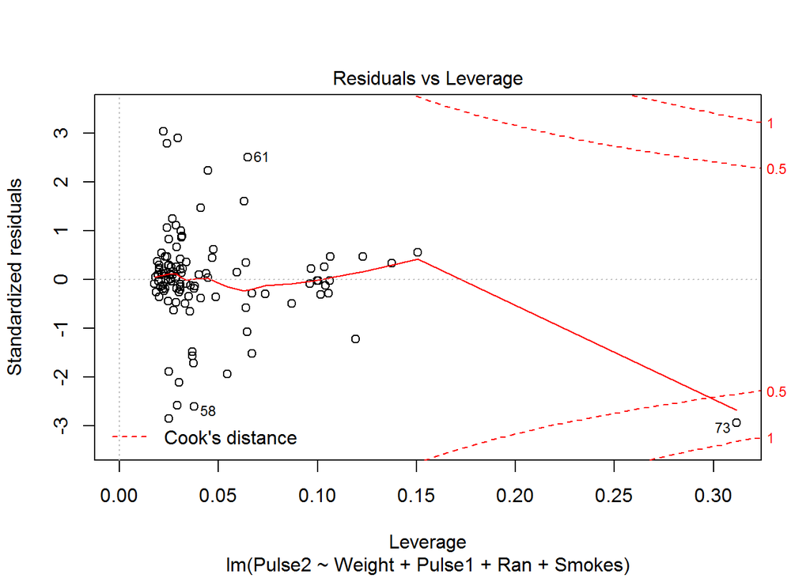

```r
plot(model_ur)
```

```r
resid(model_ur_rob)
```

Сравнение двух робастно оценённых моделей:

```r
waldtest(model_r_rob, model_ur_rob)
```

| Res.Df | Df | Chisq | Pr(>Chisq) |
| --- | --- | --- | --- |
| 107 |  |  |  |
| 104 | 3 | 293 | 3.32e-63 |

Второй способ с использование опции и изначальными моделями, оценёнными без поправки на гетероскадастичность.

```r
coeftest(model_ur, vcov. = vcovHC)
```

```
##
## t test of coefficients:
##
##               Estimate Std. Error  t value  Pr(>|t|)
## (Intercept)  56.125722  21.191573   2.6485  0.009345 **
## Weight        0.021875   0.095912   0.2281  0.820039
## Pulse1        0.894167   0.217629   4.1087 7.954e-05 ***
## Ran2        -52.202870   3.252667 -16.0492 < 2.2e-16 ***
## Smokes2       1.908051   2.516461   0.7582  0.450029
## ---
## Signif. codes:  0 '***' 0.001 '**' 0.01 '*' 0.05 '.' 0.1 ' ' 1
```

```r
coefci(model_ur, vcov. = vcovHC)
```

```
##                   2.5 %      97.5 %
## (Intercept)  14.1020380  98.1494057
## Weight       -0.1683218   0.2120713
## Pulse1        0.4626001   1.3257342
## Ran2        -58.6530314 -45.7527089
## Smokes2      -3.0821863   6.8982876
```

Тест на гетероскедастичность

Результаты в R чуть отличаются от результатов в stata. По-умолчанию, R использует корректировку HC3 для подсчёта стандартных ошибок коэффициентов, а stata — менее удачную, устаревшую HC1. Сравнение есть у [Achim Zeileis](https://cran.r-project.org/web/packages/sandwich/vignettes/sandwich.pdf). Если хочется воспроизвести именно корректировку HC1, то запросто :)

```r
coeftest(model_ur, vcov. = vcovHC(model_ur, type = "HC1"))
```

```
##
## t test of coefficients:
##
##               Estimate Std. Error  t value  Pr(>|t|)
## (Intercept)  56.125722  16.388352   3.4247 0.0008819 ***
## Weight        0.021875   0.084090   0.2601 0.7952746
## Pulse1        0.894167   0.165376   5.4069 4.111e-07 ***
## Ran2        -52.202870   3.121163 -16.7255 < 2.2e-16 ***
## Smokes2       1.908051   2.250136   0.8480 0.3984014
## ---
## Signif. codes:  0 '***' 0.001 '**' 0.01 '*' 0.05 '.' 0.1 ' ' 1
```

Сравним две исходных модели с учётом поправки на гетероскедастичность:

```r
waldtest(model_r, model_ur, vcov = vcovHC)
```

| Res.Df | Df | F | Pr(>F) |
| --- | --- | --- | --- |
| 107 |  |  |  |
| 104 | 3 | 91.8 | 4.24e-29 |

- Какая модель предпочтительнее?
- Упражнение 8.

Получите таблицу с тестами на значимость коэффициентов в модели `house_ur`, используя корректировку `HC3`. А затем сравните две модели `house_r` и `house_ur` с учётом поправки на гетероскедастичность.

```r
# coeftest(___, vcov. = ___, type = ____)
# waldtest(___, ___, vcov =  vcovHC)
```

# Инструментальные переменные

Исследователи всегда мечтают обнаружить не просто статистическую связь, а причинно-следственную. Проще всего было бы обнаружить связь с помощью рандомизированного эксперимента: поделить случайно индивидов случайно на две группы, одну попросить стирать обычным порошком, а вторую — новым чудопорошком. Важно упаковать порошки совершенно одинаково и говорить одни и те же слова :)

Мы часто имеем с данными наблюдений. Рандомизированного эксперимента при этом не было. В редких случаях можно попытаться обнаружить причинно-следственную связь на данных наблюдений.

Рассмотрим набор данных по предложению труда женщин `Mroz` из пакета `Ecdat`.

```r
glimpse(Mroz)
```

```
## Observations: 753
## Variables: 18
## $ work       <fct> no, no, no, no, no, no, no, no, no, no, no, no, no,...
## $ hoursw     <int> 1610, 1656, 1980, 456, 1568, 2032, 1440, 1020, 1458...
## $ child6     <int> 1, 0, 1, 0, 1, 0, 0, 0, 0, 0, 0, 0, 1, 0, 0, 0, 0, ...
## $ child618   <int> 0, 2, 3, 3, 2, 0, 2, 0, 2, 2, 1, 1, 2, 2, 1, 3, 2, ...
## $ agew       <int> 32, 30, 35, 34, 31, 54, 37, 54, 48, 39, 33, 42, 30,...
## $ educw      <int> 12, 12, 12, 12, 14, 12, 16, 12, 12, 12, 12, 11, 12,...
## $ hearnw     <dbl> 3.3540, 1.3889, 4.5455, 1.0965, 4.5918, 4.7421, 8.3...
## $ wagew      <dbl> 2.65, 2.65, 4.04, 3.25, 3.60, 4.70, 5.95, 9.98, 0.0...
## $ hoursh     <int> 2708, 2310, 3072, 1920, 2000, 1040, 2670, 4120, 199...
## $ ageh       <int> 34, 30, 40, 53, 32, 57, 37, 53, 52, 43, 34, 47, 33,...
## $ educh      <int> 12, 9, 12, 10, 12, 11, 12, 8, 4, 12, 12, 14, 16, 12...
## $ wageh      <dbl> 4.0288, 8.4416, 3.5807, 3.5417, 10.0000, 6.7106, 3....
## $ income     <int> 16310, 21800, 21040, 7300, 27300, 19495, 21152, 189...
## $ educwm     <int> 12, 7, 12, 7, 12, 14, 14, 3, 7, 7, 12, 14, 16, 10, ...
## $ educwf     <int> 7, 7, 7, 7, 14, 7, 7, 3, 7, 7, 3, 7, 16, 10, 7, 10,...
## $ unemprate  <dbl> 5.0, 11.0, 5.0, 5.0, 9.5, 7.5, 5.0, 5.0, 3.0, 5.0, ...
## $ city       <fct> no, yes, no, no, yes, yes, no, no, no, no, no, no, ...
## $ experience <int> 14, 5, 15, 6, 7, 33, 11, 35, 24, 21, 15, 14, 0, 14,...
```

Отберём работавших женщин.

```r
labor <- filter(Mroz, wagew > 0)
```

Мы хотим оценить причинно-следственный эффект от дополнительного года обучения на заработную плату женщины.

На первый взгляд разумно попробовать обычный МНК:

```r
model_lm <- lm(data = labor, log(wagew) ~ educw + experience + I(experience^2))
summary(model_lm)
```

```
##
## Call:
## lm(formula = log(wagew) ~ educw + experience + I(experience^2),
##     data = labor)
##
## Residuals:
##      Min       1Q   Median       3Q      Max
## -1.22168 -0.22193  0.00529  0.24018  1.17754
##
## Coefficients:
##                   Estimate Std. Error t value Pr(>|t|)
## (Intercept)      0.0310084  0.1295490   0.239  0.81098
## educw            0.0834844  0.0090775   9.197  < 2e-16 ***
## experience       0.0238019  0.0087690   2.714  0.00699 **
## I(experience^2) -0.0003113  0.0002532  -1.229  0.21983
## ---
## Signif. codes:  0 '***' 0.001 '**' 0.01 '*' 0.05 '.' 0.1 ' ' 1
##
## Residual standard error: 0.3784 on 332 degrees of freedom
## Multiple R-squared:  0.2524, Adjusted R-squared:  0.2457
## F-statistic: 37.37 on 3 and 332 DF,  p-value: < 2.2e-16
```

Эта регрессия прекрасно оценивает силу статистической взаимосвязи и показывает, насколько различается зарплата двух женщин, у которых разное образование, и одинаковый опыт работы.

Эта регрессия вовсе не говорит, насколько увеличится зарплата данной женщины, если она надумает ещё год поучиться.

Проблема состоит в ненаблюдаемых характеристиках, например, в способностях жещнины. Логично предположить, что ненаблюдаемые способности связаны положительно и с зарплатой и с продолжительностью обучения.

При всей спорности предположения, будем считать, что
$$\log(wagew_i) = \beta_1 + \beta_2 educw_i + \beta_3 experience_i +
\beta_4 experience_i^2 + \beta_5 ability_i + u_i,$$
где ошибка $u_i$ некоррелирована с остальными переменными в правой части.

Предположим, что образование матери и отца, `educwm` и `educwf` не коррелированы с ошибкой $u_i$. Тогда их можно использовать как инструменты для переменной `educw_i`.

В качестве инструментальных переменных для `educw` возьмём образование матери и отца, `educwm` и `educwf`:

```r
model_iv <- ivreg(data = labor,
  log(wagew) ~ educw + experience + I(experience^2) |
    experience + I(experience^2) + educwm + educwf)
summary(model_iv, diagnostics = TRUE)
```

```
##
## Call:
## ivreg(formula = log(wagew) ~ educw + experience + I(experience^2) |
##     experience + I(experience^2) + educwm + educwf, data = labor)
##
## Residuals:
##     Min      1Q  Median      3Q     Max
## -1.2646 -0.2287  0.0176  0.2501  1.1828
##
## Coefficients:
##                   Estimate Std. Error t value Pr(>|t|)
## (Intercept)     -0.0924839  0.2642086  -0.350  0.72653
## educw            0.0934865  0.0207397   4.508  9.1e-06 ***
## experience       0.0232873  0.0088372   2.635  0.00881 **
## I(experience^2) -0.0002929  0.0002560  -1.144  0.25335
##
## Diagnostic tests:
##                  df1 df2 statistic  p-value
## Weak instruments   2 331    39.395 4.49e-16 ***
## Wu-Hausman         1 331     0.288    0.592
## Sargan             1  NA     0.136    0.713
## ---
## Signif. codes:  0 '***' 0.001 '**' 0.01 '*' 0.05 '.' 0.1 ' ' 1
##
## Residual standard error: 0.3791 on 332 degrees of freedom
## Multiple R-Squared: 0.2497,  Adjusted R-squared: 0.2429
## Wald test: 15.91 on 3 and 332 DF,  p-value: 1.085e-09
```

После вертикальной палочки `|` в команде `ivreg` указывают экзогенные переменные, используемые в качестве инструментов.

Если верить в то, что образование матери и отца некоррелировано с ненаблюдаемыми способностями женщины, тогда коэффициент при образовании женщины `educw` показывает, насколько изменится зарплата женщины при увеличении образования на один год, постоянном опыте и постоянных способностях.

Автоматически команда `summary` с опцией `diagonostics = TRUE` проводит три теста:

1. Тест на слабые инструменты

Нулевая гипотеза: $H_0$: инструментальные переменные не коррелированы с потенциально эндогенным регрессором

2. Тест Хаусмана на равенство оценок IV и обычного МНК.

Нулевая гипотеза: $H_0$: ковариация потенциально эндогенного регрессора с ошибкой равна нулю.

3. Тест Саргана

Нулевая гипотеза: $H_0$: инструментальные переменные правильно подобраны, то есть они не коррелированы с ошибкой, а невключённые инструменты и не должны быть включены в модель.

- Какие гипотезы отвергаются, какие не отвергаются в нашем случае?

Легко использовать IV с робастными к гетероскедастичности ошибками

```r
summary(model_iv, diagnostics = TRUE, vcov. = vcovHC)
```

```
##
## Call:
## ivreg(formula = log(wagew) ~ educw + experience + I(experience^2) |
##     experience + I(experience^2) + educwm + educwf, data = labor)
##
## Residuals:
##     Min      1Q  Median      3Q     Max
## -1.2646 -0.2287  0.0176  0.2501  1.1828
##
## Coefficients:
##                   Estimate Std. Error t value Pr(>|t|)
## (Intercept)     -0.0924839  0.2568502  -0.360  0.71902
## educw            0.0934865  0.0207925   4.496 9.57e-06 ***
## experience       0.0232873  0.0086521   2.692  0.00747 **
## I(experience^2) -0.0002929  0.0002538  -1.154  0.24928
##
## Diagnostic tests:
##                  df1 df2 statistic  p-value
## Weak instruments   2 331    34.686 2.11e-14 ***
## Wu-Hausman         1 331     0.269    0.604
## Sargan             1  NA     0.136    0.713
## ---
## Signif. codes:  0 '***' 0.001 '**' 0.01 '*' 0.05 '.' 0.1 ' ' 1
##
## Residual standard error: 0.3791 on 332 degrees of freedom
## Multiple R-Squared: 0.2497,  Adjusted R-squared: 0.2429
## Wald test: 20.21 on 3 and 332 DF,  p-value: 4.733e-12
```

Есть и отдельная функция в пакете `estimatr`:

```r
model_iv_robust <- iv_robust(data = labor,
  log(wagew) ~ educw + experience + I(experience^2) |
    experience + I(experience^2) + educwm + educwf)
summary(model_iv_robust)
```

```
##
## Call:
## iv_robust(formula = log(wagew) ~ educw + experience + I(experience^2) |
##     experience + I(experience^2) + educwm + educwf, data = labor)
##
## Standard error type:  HC2
##
## Coefficients:
##                   Estimate Std. Error  Pr(>|t|)   CI Lower  CI Upper  DF
## (Intercept)     -0.0924839  0.2549478 7.170e-01 -0.5940007 0.4090329 332
## educw            0.0934865  0.0206390 8.252e-06  0.0528868 0.1340863 332
## experience       0.0232873  0.0085373 6.717e-03  0.0064932 0.0400813 332
## I(experience^2) -0.0002929  0.0002493 2.407e-01 -0.0007833 0.0001974 332
##
## Multiple R-squared:  0.2497 ,    Adjusted R-squared:  0.2429
## F-statistic: 20.53 on 3 and 332 DF,  p-value: 3.151e-12
```

- Упражнение 9.

Для упражнения возьмём данные о потреблении сигарет в США `CigaretteeSW` из пакета `AER`. Его описание можно прочесть в справке!

Возьмём наблюдения только за 1995 год и создадим несколько новых переменных: логарифм реальных цен `lrprice`, логарифм дохода на душу населения `lrincome`, логарифм количества пачек сигарет на человека `lquant` и реальный налог на сигареты `tdiff`.

```r
data("CigarettesSW")
cig <- subset(CigarettesSW, year == 1995)
cig$lrprice <- log(cig$price / cig$cpi)
cig$lrincome <- log(cig$income / cig$population / cig$cpi)
cig$lquant <- log(cig$packs)
cig$tdiff <- (cig$taxs - cig$tax) / cig$cpi

# glimpse(___)
# skim(___)
```

Постройте регрессию логарифма количества пачек сигарет на человека `lquant` на логарифм реальной цены одной пачки `lrprice`, используя в качестве инстурмента реальный налог `tdiff`.

```r
# cig_iv1 <- ivreg(data = ___, ___ ~ ___ | ___)
# summary(___, diagnostics = ___)
```

Добавьте к объясняющим переменным логарифм реального дохода на душу населения `lrincome`, а к инструментам — реальный налог на сигареты `tax / cpi`.

```r
# cig_iv2 <- ivreg(data = ___, ___ ~ ___ + ___ | ____ + ___ + I(tax/cpi))
# summary(___, ___ = ___)
```

Мы доносим информацию до читателя в графиках, таблицах и тексте.

R позволяет создавать документы в совершенно разных форматах, мы познакомимся с тремя: html, docx, tex.

# Формат html

Прелесть html состоит в богатстве оформления и динамических элементах.

Начнём с нескольких таблиц.

Составим по-быстрому табличку описательных статистик:

```r
skim_to_wide(diamonds) %>%
  filter(type != 'factor') %>%
  select(variable, complete, mean, sd, p0, p50, hist) %>%
  hux(add_colnames = TRUE) %>% print_html()
```

| variable | complete | mean | sd | p0 | p50 | hist |
| --- | --- | --- | --- | --- | --- | --- |
| price | 53940 | 3932.8 | 3989.44 | 326 | 2401 |  |
| carat | 53940 | 0.8 | 0.47 | 0.2 | 0.7 |  |
| depth | 53940 | 61.75 | 1.43 | 43 | 61.8 |  |
| table | 53940 | 57.46 | 2.23 | 43 | 57 |  |
| x | 53940 | 5.73 | 1.12 | 0 | 5.7 |  |
| y | 53940 | 5.73 | 1.14 | 0 | 5.71 |  |
| z | 53940 | 3.54 | 0.71 | 0 | 3.53 |  |

Оформляем наши таблички симпатичнее:

```r
htmlreg(list(model_r, model_ur, model_r_rob, model_ur_rob),
        include.ci = FALSE,
        star.symbol = '\\*')
```

Statistical models

|  | **Model 1** | **Model 2** | **Model 3** | **Model 4** |  |
| --- | --- | --- | --- | --- | --- |
| (Intercept) | 31.85 | 56.13*** | 31.85* | 56.13** |  |
|  | (16.44) | (12.15) | (14.25) | (18.32) |  |
| Pulse1 | 0.86*** | 0.89*** | 0.86*** | 0.89*** |  |
|  | (0.21) | (0.10) | (0.19) | (0.19) |  |
| Weight |  | 0.02 |  | 0.02 |  |
|  |  | (0.09) |  | (0.09) |  |
| Ran2 |  | -52.20*** |  | -52.20*** |  |
|  |  | (2.75) |  | (3.14) |  |
| Smokes2 |  | 1.91 |  | 1.91 |  |
|  |  | (4.52) |  | (2.35) |  |
| R<sup>2</sup> | 0.13 | 0.81 | 0.13 | 0.81 |  |
| Adj. R<sup>2</sup> | 0.12 | 0.80 | 0.12 | 0.80 |  |
| Num. obs. | 109 | 109 | 109 | 109 |  |
| RMSE | 29.57 | 14.10 | 29.57 | 14.10 |  |
| ***p < 0.001, **p < 0.01, *p < 0.05 |  |  |  |  |  |

Вариант с доверительными интервалами:

```r
htmlreg(list(model_r, model_ur, model_r_rob, model_ur_rob), ci.force = TRUE)
```

Statistical models

|  | **Model 1** | **Model 2** | **Model 3** | **Model 4** |  |
| --- | --- | --- | --- | --- | --- |
| (Intercept) | 31.85 | 56.13* | 31.85* | 56.13* |  |
|  | [-0.38; 64.07] | [32.32; 79.94] | [3.59; 60.10] | [19.79; 92.46] |  |
| Pulse1 | 0.86* | 0.89* | 0.86* | 0.89* |  |
|  | [0.44; 1.28] | [0.69; 1.10] | [0.49; 1.23] | [0.52; 1.26] |  |
| Weight |  | 0.02 |  | 0.02 |  |
|  |  | [-0.16; 0.20] |  | [-0.15; 0.20] |  |
| Ran2 |  | -52.20* |  | -52.20* |  |
|  |  | [-57.60; -46.81] |  | [-58.43; -45.97] |  |
| Smokes2 |  | 1.91 |  | 1.91 |  |
|  |  | [-6.95; 10.77] |  | [-2.75; 6.56] |  |
| R<sup>2</sup> | 0.13 | 0.81 | 0.13 | 0.81 |  |
| Adj. R<sup>2</sup> | 0.12 | 0.80 | 0.12 | 0.80 |  |
| Num. obs. | 109 | 109 | 109 | 109 |  |
| RMSE | 29.57 | 14.10 | 29.57 | 14.10 |  |
| * 0 outside the confidence interval |  |  |  |  |  |

Просто картинка в html с подписями и ссылкой:

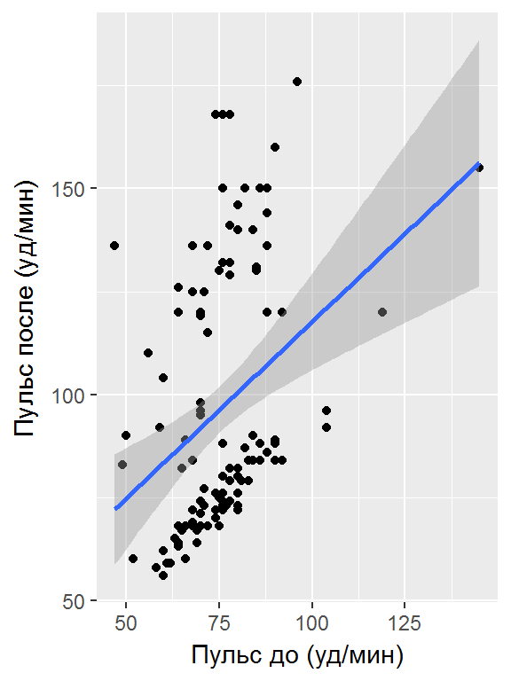

```r
ggplot(data = pulse_fct, aes(x = Pulse1, y = Pulse2)) +
  geom_point() +
  geom_smooth(method = 'lm') + labs(x = 'Пульс до (уд/мин)', y = 'Пульс после (уд/мин)')
```

Для примера процитируем несколько источников, Einstein et al. (1935), Афанасьев and Василевский (1992), Cobb (2011), Гультяев (2008), Doe and Pam (2011).

Другие стилевые заготовки для оформления цитат можно скачать в архиве [zotero](https://www.zotero.org/styles).

Примеры таблиц для html с [пакетом huxtable](https://hughjonesd.github.io/huxtable/), интерактивные элементы, например, карты, с [htmlwidgets](http://gallery.htmlwidgets.org).

И библиографию в студию:

Cobb, G.W., 2011. Teaching statistics: Some important tensions. Chilean Journal of Statistics 2, 31–62.

Doe, J., Pam, S., 2011. The website title.

Einstein, A., Podolsky, B., Rosen, N., 1935. Can quantum-mechanical description of physical reality be considered complete? Physical review 47, 777.

Афанасьев, В.В., Василевский, О.Н., 1992. Расчеты электрических цепей на программируемых микрокалькуляторах. Энергоиздат, Москва.

Гультяев, А., 2008. Microsoft office project 2007 professional. управление проектами: Практическое пособие. СПб:.КОРОНА-Век.